```python
%matplotlib inline
import matplotlib.pyplot as plt
import numpy as np
```

This exercise consists of 3 parts. Finish the first part to get the mark of 3.0. The first 2 parts to get 4.0. Finish all parts to get 5.0.

# Part 1: Linear layer

1.1) Let us start with a linear regression problem. Consider a linear function with a noise: $y = a*x+b + noise$.

We use this formula to generate $100$ random samples.

```python
### The number of samples
n = 100
### parameters of the linear function
a = -2
b = 3
```

1.2) Now, let us generate 100 samples and plot them.

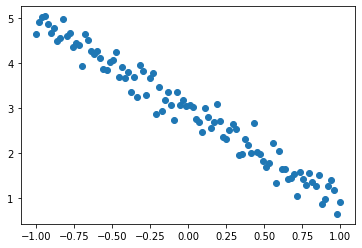

```python
### generate equally spaced x-values
x = np.linspace(-1, 1, n)
### generate y-values (we use a numpy library so we can generate a vector of numbers - y - inline)
y = a * x + b + np.random.normal(scale=0.25, size=n)

plt.scatter(x, y)
```

1.3) As you may see, the samples are placed - more or less - along a single line. Now, our aim is to find the best parameters for a linear function so that such defined model describes the given data in the best possible way. For this reason, we will iteratively search the parameter space and thus update the model. Firstly, we need to define an error function. This function will inform how well (or bad) the instantiated model describes the data. For this reason, we use a mean square error function.

We define a mean square error function as:  
$\dfrac{\sum\left(y_i - \widehat{y}_i \right)^2}{n} = MSE,$

where $y$ are the target (i.e., data values) and $\widehat{y}$ are the output (i.e., model's) values.

See the MSE (mean square error) function given below.

```python
def mse(y_target, y_calc):
    return ((y_target - y_calc) ** 2).mean()
```

1.4) Run the below code for different parameters of the model. Which parameter values give the best (i.e., minimal) MSE?

```
MSE = 0.05240070137073226, for a = -2.0 and b = 3.0
```

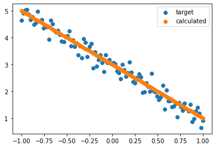

```python
a_list = [-3.0 + i*0.25 for i in range(13)]
b_list = [-4.0 + i*0.5 for i in range(19)]
best_score = np.inf
best_ycalc = None
best_a = None
best_b = None
for a_2 in a_list:
    for b_2 in b_list:
        # print(f'{a_2}x + {b_2}')
        ycalc = a_2*x + b_2
        score = mse(y, ycalc)
        if score < best_score:
            # print("\tbetter")
            best_a = a_2
            best_b = b_2
            best_score = score
            best_ycalc = ycalc
print(f'MSE = {best_score}, for a = {best_a} and b = {best_b}')

plt.scatter(x, y, label="target")
plt.scatter(x, best_ycalc, label="calculated")
plt.legend()

y_calc = best_ycalc
```

1.5) We want to find the best possible model parameters automatically. For this reason, we use a gradient of a loss function. The gradient informs what is the direction of the fastest increase/decrease of a given function. We use this information to update both model parameters. This procedure will be performed iterativelly. In each iteration, the parameters a and b will be slightly modififed such that MSE will be reduced (i.e., improved).

Firstly, finish the below function. It should calculate a batch gradient of a loss function, i.e., **MSE for each point separately** (y_target, and y_calc are array, not just scalars, so output also should be array).

```python
def mse_grad(y_target, y_calc):
    # n = len(y_target)
    # errors = [0.0 for i in range(n)]
    # for i in range(n):
    #     errors[i] = mse(y_target[i], y_calc[i])
    return (2 / len(y_target)) * (y_calc - y_target)


### TEST
print(mse_grad(y, y_calc))
```

```
[ 6.93856969e-03  8.11702135e-04 -2.09227261e-03 -3.19746111e-03
 -5.47597620e-04  2.44628640e-03 -4.99323542e-04  4.41815696e-03
  2.33913324e-03 -6.88979781e-03 -3.78478059e-06 -2.21161964e-03
  3.10503918e-03  4.10480982e-04  5.85606550e-04  9.26508990e-03
 -5.70263781e-03 -3.89168319e-03  2.82520335e-04  6.96776734e-04
 -1.48515081e-03  8.63071106e-04  4.84306794e-03  4.34554430e-03
  3.77695381e-04 -1.37930813e-03 -6.11712694e-03  4.22639528e-03
 -7.97688986e-04  3.03772592e-03 -8.43715165e-05  7.69589689e-03
  4.14237023e-04  8.50977614e-03 -6.77577621e-03 -4.66820572e-03
  5.29426482e-03 -3.15113598e-03 -6.20091913e-03  1.10324080e-02
 -1.86101259e-03  8.12382119e-03  2.61461129e-03 -1.79697150e-03
  2.93131885e-03  9.04420016e-03 -4.16864772e-03  5.25856128e-04
 -2.46271648e-03 -4.60933961e-04 -1.58931432e-03 -1.59043982e-03
  2.89034001e-03  3.57962721e-03  6.79416054e-03 -4.40761582e-03
 -1.22588787e-03  2.84437023e-03 -8.78921237e-04 -9.67106698e-03
 -2.75620252e-03  3.73889389e-03  3.73889785e-03 -1.12687857e-03
 -4.58098610e-03 -3.10446571e-03  7.40977682e-03  6.27116358e-03
 -1.12540838e-03  8.39644868e-04  3.32259606e-03 -1.06153929e-02
  1.12368538e-03  1.26269449e-03  3.81225925e-03  5.75696589e-03
  2.89096693e-03 -6.62090852e-03  1.03768110e-02 -4.82943376e-03
  2.31627050e-03  1.78838518e-03  5.29651063e-03  3.94805769e-03
  1.35240164e-03  1.03893893e-02 -1.22147121e-03  1.19851359e-03
  3.22031166e-03 -3.23344932e-03  3.98608984e-05  9.77381966e-04
 -4.46782651e-03  7.38732874e-03  4.42788397e-03 -2.05444028e-03
 -5.57935043e-03 -1.78418400e-03  7.83576230e-03  1.72261348e-03]
```

1.6) Fill the update function to calculate gradient of parameter $a$ and $b$ basing on a gradient of loss function (grad_y) and input vector (x). Then update the parameter $a$ and $b$ base on their gradients and learning rate (lr). To update parameters use batch gradient descent.

```python
class LinearLayer:
    def __init__(self, a, b):
        self.a = a
        self.b = b

    def __call__(self, x):
        return self.a * x + self.b

    def update(self, x, grad_y, lr):
        shift_a = sum(grad_y * x)
        shift_b = sum(grad_y)
        self.a -= lr * shift_a
        self.b -= lr * shift_b
```

1.7) Write Step function which calculates: y_calc output of the model base on input x, loss of the model, gradient of loss, and update the model parameters.

```python
def Step(x, y, model, lr):
    y_calc = model(x)
    loss = mse(y, y_calc)
    model.update(x, mse_grad(y, y_calc), lr)

    return y_calc, loss
```

1.8) Fit the model for 100 epochs, with learning rate 0.05, and with initial value of parameters a = 1.1, and b = 2.

```python
model = LinearLayer(1.1, 2)
```

```python
lr = 0.05
```

```python
epoch = 100
losses = []
for i in range(epoch):
    y_calc, loss = Step(x, y, model, lr)
    losses.append(loss)
```

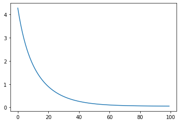

```python
plt.plot(losses)
```

Animation of the learning process

```python
from matplotlib import animation, rc
rc('animation', html='jshtml')
```

```python
model = LinearLayer(1.1, 2)
```

```python
fig = plt.figure()
plt.scatter(x, y)
line, = plt.plot(x, y_calc, ".", c="orange")
plt.close()


def animate(i):
    y_calc, loss = Step(x, y, model, lr)
    line.set_ydata(y_calc)
    return (line,)


animation.FuncAnimation(fig, animate, np.arange(0, epoch), interval=20)
```

[figure not shown]

1.9) There is an example it can be done in pytorch.

```python
# Imports
import torch
import torch.nn as nn
```

[output not shown]

```python
# Convert numpy array to torch tensor, [:,None] add an additional dimension
xt = torch.FloatTensor(x[:, None])
yt = torch.FloatTensor(y[:, None])
```

```python
def mse(y_target, y_calc):
    return ((y_target - y_calc) ** 2).mean()
```

```python
class LinearLayer(nn.Module):
    def __init__(self, a, b):
        super(LinearLayer, self).__init__()  # initialize torch functionality
        # change a and b to float tensor, and next to parameters,
        # the main difference between tensor and parameter is that parameter keeps information about calculations,
        # which is used to calculate gradients
        self.a = nn.Parameter(torch.FloatTensor([a]).view(1, 1))
        self.b = nn.Parameter(torch.FloatTensor([b]))

    # forward function is similar to python __call__ but also contain torch functionality
    def forward(self, x):
        return  x @ self.a + self.b  # linear equation, @ means matrix multiplication for tensor

    def update(self, lr):
        with torch.no_grad():  # when we update parameter, we have to switch off gradient tracking
            self.a.sub_(lr * self.a.grad)  # inplace update of parameter a
            self.a.grad.zero_()  # clear gradient

            self.b.sub_(lr * self.b.grad)
            self.b.grad.zero_()
```

```python
model =  LinearLayer(-1.1, 0.2)
```

```python
def torchStep(x, y, model, lr):
    y_calc = model(x)  # calculate the output of our model
    loss = mse(y, y_calc)  # calculate the loss
    loss.backward()  # calculate all gradients
    model.update(lr)  # update parameters
    return loss, y_calc
```

```python
loss, y_calc = torchStep(xt, yt, model, lr)
y_calc = y_calc.detach().cpu()
fig = plt.figure()
plt.scatter(xt[:, 0], yt)
line, = plt.plot(xt[:, 0], y_calc, c="orange")
plt.close()


def animate(i):
    loss, y_calc = torchStep(xt, yt, model, lr)
    y_calc = y_calc.detach().cpu()  #
    line.set_ydata(y_calc)
    return (line,)


animation.FuncAnimation(fig, animate, np.arange(0, 100), interval=20)
```

[output not shown]

```python
# we can use optymalizer to update parameters base on their gradients
# the most simple is stochastic gradient descent (SGD)
def torchStep2(x, y, model, optim):
    optim.zero_grad()  # clear gradients
    y_calc = model(x)  # calculate output of model
    loss = mse(y, y_calc)  # calculate loss
    loss.backward()  # calculate all gradients
    optim.step()  # make a optymalizer step which update parameters
    return loss, y_calc
```

```python
model = LinearLayer(-1.1, 0.2)
optim = torch.optim.SGD(model.parameters(), lr)
```

```python
loss, y_calc = torchStep2(xt, yt, model, optim)
y_calc = y_calc.detach().cpu()
fig = plt.figure()
plt.scatter(xt[:, 0], yt)
line, = plt.plot(xt[:, 0], y_calc, c="orange")
plt.close()


def animate(i):
    loss, y_calc = torchStep2(xt, yt, model, optim)
    y_calc = y_calc.detach().cpu()
    line.set_ydata(y_calc)
    return (line,)


animation.FuncAnimation(fig, animate, np.arange(0, 100), interval=20)
```

[output not shown]

# Part 2: Convolution layer

```python
# input image
image = np.array(
    [
        [0, 0, 0, 0, 0, 1, 0, 0, 0, 0, 0, 0, 0, 0, 0, 0, 0, 0, 0, 0],
        [0, 0, 0, 0, 0, 1, 0, 0, 0, 0, 0, 0, 1, 1, 1, 1, 1, 1, 0, 0],
        [0, 0, 0, 0, 0, 1, 0, 0, 0, 0, 0, 0, 1, 0, 0, 0, 0, 1, 0, 0],
        [0, 0, 0, 0, 0, 1, 0, 0, 0, 0, 0, 0, 1, 0, 0, 0, 0, 1, 0, 0],
        [0, 0, 0, 0, 0, 1, 0, 0, 0, 0, 0, 0, 1, 0, 0, 0, 0, 1, 0, 0],
        [0, 0, 0, 0, 0, 1, 0, 0, 0, 0, 0, 0, 1, 0, 0, 0, 0, 1, 0, 0],
        [0, 0, 0, 0, 0, 1, 0, 0, 0, 0, 0, 0, 1, 1, 1, 1, 1, 1, 0, 0],
        [1, 0, 0, 0, 0, 1, 0, 0, 0, 0, 0, 0, 0, 0, 0, 0, 0, 0, 0, 0],
        [0, 1, 0, 0, 0, 1, 0, 0, 0, 0, 0, 0, 0, 0, 0, 0, 0, 0, 0, 0],
        [0, 0, 1, 0, 0, 1, 0, 0, 0, 0, 0, 0, 0, 0, 0, 0, 0, 0, 0, 0],
        [1, 1, 1, 1, 1, 1, 1, 1, 1, 1, 1, 1, 1, 1, 1, 1, 1, 1, 1, 1],
        [0, 0, 0, 0, 1, 1, 0, 0, 0, 0, 0, 0, 0, 0, 0, 0, 0, 0, 0, 0],
        [0, 0, 0, 0, 0, 1, 0, 0, 0, 0, 0, 0, 0, 0, 0, 0, 0, 0, 0, 0],
        [0, 0, 0, 0, 0, 1, 1, 0, 0, 0, 0, 0, 0, 0, 0, 0, 0, 0, 0, 0],
        [0, 0, 0, 0, 0, 1, 0, 1, 0, 0, 0, 0, 0, 0, 0, 1, 0, 0, 0, 1],
        [0, 0, 0, 0, 0, 1, 0, 0, 1, 0, 0, 0, 0, 0, 0, 0, 0, 0, 1, 0],
        [0, 0, 0, 0, 0, 1, 0, 0, 0, 1, 0, 0, 0, 0, 0, 0, 0, 1, 0, 0],
        [0, 0, 0, 0, 0, 1, 0, 0, 0, 0, 1, 0, 0, 0, 0, 0, 1, 0, 0, 0],
        [0, 0, 0, 0, 0, 1, 0, 0, 0, 0, 0, 1, 0, 0, 0, 1, 0, 0, 0, 0],
        [0, 0, 0, 0, 0, 1, 0, 0, 0, 0, 0, 0, 1, 0, 1, 0, 0, 0, 0, 0],
    ]
)
```

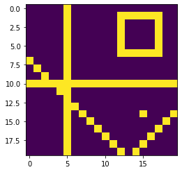

```python
plt.imshow(image)
```

2.1) Write a function which calculates a convolution on an input matrix (image) using kernel (mask) with shape 3x3 and bias. Do not use padding, so the output image should be in size: (input_wight -2) x (input_height -2).

```python
def Convolution(image, kernel, bias):
    img_out = np.zeros((image.shape[0] - 2, image.shape[1] - 2))
    for i in range(image.shape[0] - 2):
        for j in range(image.shape[1] - 2):
            out = 0
            for k in range(3):
                for l in range(3):
                    out += image[i + k][j + l] * kernel[k][l]
            out += bias
            img_out[i][j] = out

    return img_out
```

```python
# kernel (mask) which is mean filter
kernel = np.ones((3, 3)) / 9
kernel
```

```
array([[0.11111111, 0.11111111, 0.11111111],
       [0.11111111, 0.11111111, 0.11111111],
       [0.11111111, 0.11111111, 0.11111111]])
```

```python
bias = -0.5
```

```python
img_out = Convolution(image, kernel, bias)
```

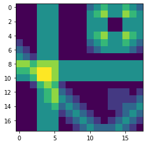

```python
plt.imshow(img_out)
```

2.2) Find out kernels (masks) which found horizontal and vertical lines. Pixels belonging to the line should be greater than zero and the others less than zero. Use size 3x3 masks.

Example  
print(Convolution(np.array([[0,0,0,0,0],[0,0,0,0,0],[1,1,1,1,1],[0,0,0,0,0],[0,0,0,0,0]]), kernel_horizontal, -2))  
[[-1. -1. -1.]  
[ 1. 1. 1.]  
[-1. -1. -1.]]

```python
kernel_horizontal = np.array([[0, 0, 0], [1, 1.5, 1], [0, 0, 0]])
```

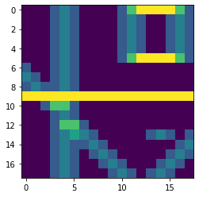

```python
img_horizontal = Convolution(image, kernel_horizontal, -2)
plt.imshow(img_horizontal)
```

```python
kernel_vertical = np.array([[0, 1, 0], [0, 1.5, 0], [0, 1, 0]])
```

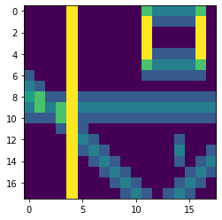

```python
img_vertical = Convolution(image, kernel_vertical, -2)
plt.imshow(img_vertical)
```

2.3) Complete function to calculate ReLU.

```python
def relu(x):
    for i in range(len(x)):
        for j in range(len(x[i])):
            if x[i][j] <= 0:
                x[i][j] = 0

    return x
```

2.4) Find bias values such that output images pixels have a value above 0 only if original pixel is a part of the horizontal/vertical line.

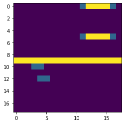

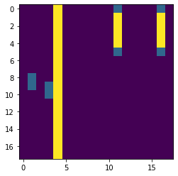

```python
plt.imshow(relu(img_horizontal))
plt.show()
plt.imshow(relu(img_vertical))
```

# Part 3: Deep network

```python
import pandas as pd
```

```python
# load iris dataset
df = pd.read_csv('data/iris.csv')
```

```python
# n - number of elements in dataset
n = len(df)
```

```python
# useful variables
feature_columns = ["sepal.length", "sepal.width", "petal.length", "petal.width"]
target_column = "variety"
class_number = 3
feature_number = 4
```

```python
# dictionaries use to map class name to number
name_to_class = {0: "Setosa", 1: "Versicolor", 2: "Virginica"}
class_to_name = {"Setosa": 0, "Versicolor": 1, "Virginica": 2}
```

```python
# conversion of class name
df[target_column] = df[target_column].apply(lambda x: class_to_name[x])
```

```python
# take raw numpy data
x = df[feature_columns].values
y = df[target_column].values
```

```python
# normalize data to make network input mean value equals 0 and standard deviation 1
x = (x - x.mean(0)) / x.std(0)
print(x.mean(0))
print(x.std(0))
```

[output not shown]

```python
# conversion numpy array to torch tensor
x = torch.FloatTensor(x)
y = torch.LongTensor(y)
```

```python
# simple neural network with one hidden layer with hidden_nr neuron
# input_layer calculate some features  which are used by hidden_layer to calculate prediction
# between input_layer and hidden_layer there is relu  as a nonlinear activation function
# after hidden_layer there is sigmoid function because we want the network to return the result as a probability of each class in range [0,1]
class Net(nn.Module):
    def __init__(self, input_nr, hidden_nr, output_nr):
        super(Net, self).__init__()
        self.input_layer = nn.Linear(input_nr, hidden_nr)
        self.hidden_layer = nn.Linear(hidden_nr, output_nr)

    def forward(self, x):
        x = self.input_layer(x)
        x = torch.relu(x)
        x = self.hidden_layer(x)
        return torch.sigmoid(x)
```

Cross entropy loss is equal $- (y=0) * log(p_0) - (y=1) * log(p_1) - (y=2) * log(p_2)$ where $p_1, p_2,p_3$ are calculated probability of class 1,2,3; and y=0 means y is classified to class 0.

```python
loss_func = nn.CrossEntropyLoss()
```

```python
# accuracy means how many samples are classified correctly
def Accuracy(y_target, y_calc):
    prediction_class = y_calc.max(1)[1]
    number_of_correct = (prediction_class == y).float().sum()
    return number_of_correct / n
```

```python
def Step(x, y, model, optim):
    optim.zero_grad()
    y_calc = model(x)
    loss = loss_func(y_calc, y)
    loss.backward()
    optim.step()
    acc = Accuracy(y, y_calc)
    return loss, y_calc, acc
```

```python
# Train function train model for epoch step, and collect metrics (loss and accuracy)
def Train(x, y, model, optim, epoch):
    losses = []
    accuracies = []
    for i in range(epoch):
        loss, y_calc, acc = Step(x, y, model, optim)
        losses.append(loss)
        accuracies.append(acc)
    return losses, accuracies
```

```python
lr = 0.1
```

```python
# create a model and optimizer
hidden_nr = 5
model = Net(feature_number, hidden_nr, class_number)
optim = torch.optim.SGD(model.parameters(), lr)
```

```python
epoch = 200
losses, accuracies = Train(x, y, model, optim, epoch)
```

```python
plt.plot(losses)
plt.show()
plt.plot(accuracies)
```

[output not shown]

## Task for 5:

Choose one of the following 3.1 or 3.2:

3.1) Create a report of testing different values of learning rate, and number of neurons in hidden layer; Run every test 10 times with 200 epochs. Make a plot of mean of losses and accuracy of each value in the test case. Make a table of score after 200 epochs of learning which should contain best, worst, mean and standard deviation of loss and accuracy (you can use pandas describe function).

```
test case 1:
learning rate:[ 1, 0.5, 0.1, 0.01, 0.001]
number of neuron in hidden layer: 10

test case 2:
number of neuron in hidden layer: [1, 2, 5, 10, 20, 100]
learning rate: 0.1
```

3.2) You can try to make an image classifier shown in fastai courses https://docs.fast.ai/

- [video](https://course.fast.ai/videos/?lesson=2)
- [notebook](https://github.com/fastai/fastbook/blob/master/02_production.ipynb)

**(old version of fastai 1.0.61 and pytorch 1.2)**

- [video](https://course17.fast.ai/lessons/lesson2.html) You should watch all video, but after 16.30 there are creating your own dataset and next create an image classifier.
- [notebook](https://github.com/fastai/course-v3/blob/master/nbs/dl1/lesson2-download.ipynb)

You can use animals dataset or prepare your own dataset, but it should contain at least 4 different classes.

```
To finish this task you should prepare a report by creating a classifier, and show working neural network at the laboratory.
The report should contain:
    - describe of dataset: number of samples, some examples, how it was prepared, number of samples in train and validation set, are there images which contains more than one class, batch size
    - describe of model: tested models
    - describe of training: how testing looks like, how many epoch, how long it takes, data cleaning, learning rate finder and so on, plots of losses, and accuracy
    - describe of result: confusion matrix, examples of correct classified image, examples of incorrect classified image
```